# 6101 Project 1

Jeffrey Hu, Aaron Rock, Sanchit Vijay

9/27/22 to 10/27/22

## Import the data

```r
#First, load the file
zillow = data.frame(read.csv("price.csv"))
head(zillow)
```

## Remove blank pricing data

```r
# Remove empty rows, NA's are only present if no data was collected for the location
zillow = na.omit(zillow)
```

## Subset the Zillow data into east coast and west coast and annual subsets of the regions.

```r
# going through and discarding states that are not defined by the Uited States as West or East coast states

eastcoast = subset(zillow, State == 'CT' | State == 'NY' | State == 'VA' | State == 'FL' | State == 'NJ' | State == 'NC' |State == 'SC' | State == 'GA' | State == 'DE' | State == 'MA' | State == 'MD' | State == 'ME' | State == 'RI' | State == 'NH')
eastcoast_annual = eastcoast[,c(1:81)]
eastcoast_annual = eastcoast_annual[-c(8,9,10,11,12,13,14,15,16,17,18)]
eastcoast_annual = eastcoast_annual[-c(9,10,11,12,13,14,15,16,17,18,19)]
eastcoast_annual = eastcoast_annual[-c(10,11,12,13,14,15,16,17,18,19,20)]
eastcoast_annual = eastcoast_annual[-c(11,12,13,14,15,16,17,18,19,20,21)]
eastcoast_annual = eastcoast_annual[-c(12,13,14,15,16,17,18,19,20,21,22)]
eastcoast_annual = eastcoast_annual[-c(13,14,15,16,17,18,19,20,21,22,23)]
eastcoast_annual = eastcoast_annual[-c(14,15)]

westcoast = subset(zillow, State == 'CA' | State == 'OR' | State == 'WA' | State == 'HI' | State == 'AK')

westcoast_annual = westcoast[,c(1:81)]
westcoast_annual = westcoast_annual[-c(8,9,10,11,12,13,14,15,16,17,18)]
westcoast_annual = westcoast_annual[-c(9,10,11,12,13,14,15,16,17,18,19)]
westcoast_annual = westcoast_annual[-c(10,11,12,13,14,15,16,17,18,19,20)]
westcoast_annual = westcoast_annual[-c(11,12,13,14,15,16,17,18,19,20,21)]
westcoast_annual = westcoast_annual[-c(12,13,14,15,16,17,18,19,20,21,22)]
westcoast_annual = westcoast_annual[-c(13,14,15,16,17,18,19,20,21,22,23)]
westcoast_annual = westcoast_annual[-c(14,15)]

westcoast = westcoast[-c(2,3,4,5,6)]

westAnn = westcoast_annual
westAnn = westAnn[-c(2,3,4,5,6)]

eastAnn = eastcoast_annual
eastAnn = eastAnn[-c(2,3,4,5,6)]
```

## Find the difference between of rent price and add it as a column AND add average price of rent over the years column

```r
# use dplyr package to create new columns Price.Diff and Avg.Price
eastcoast_annual <- eastcoast_annual %>%
    mutate(Price.Diff = November.2016 - November.2010)

westcoast_annual <- westcoast_annual %>%
    mutate(Price.Diff = November.2016 - November.2010)

eastcoast_annual <- eastcoast_annual %>%
     mutate(Avg.Price = rowMeans(eastcoast_annual[7:13]))

westcoast_annual <- westcoast_annual %>%
     mutate(Avg.Price = rowMeans(westcoast_annual[7:13]))
```

## Clean Data of Outliers

```r
# clean the data
westcoast_annualClean = outlierKD2(westcoast_annual, November.2010, rm = TRUE)
```

Outliers identified: 64 Propotion (%) of outliers: 5.5 Mean of the outliers: 5337 Mean without removing outliers: 1733 Mean if we remove outliers: 1534 Outliers successfully removed

```r
westcoast_annualClean = outlierKD2(westcoast_annualClean, November.2016, rm = TRUE)
```

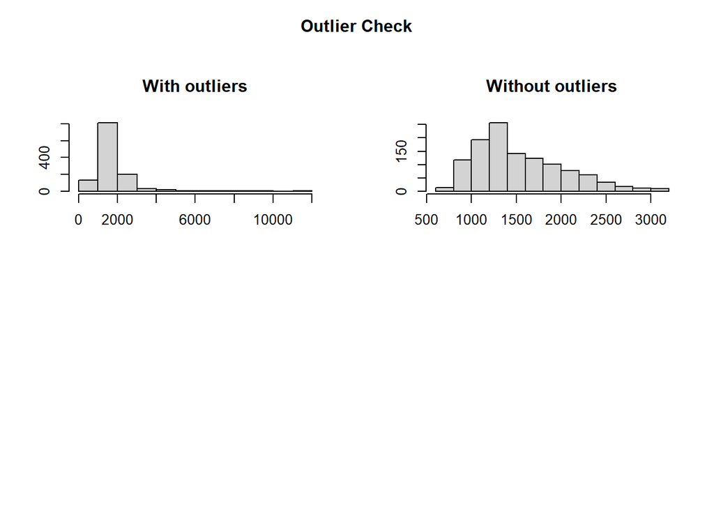

Outliers identified: 70 Propotion (%) of outliers: 6.1 Mean of the outliers: 6518 Mean without removing outliers: 2093 Mean if we remove outliers: 1823 Outliers successfully removed

```r
westcoast_annualClean = outlierKD2(westcoast_annualClean, Avg.Price, rm = TRUE)
```

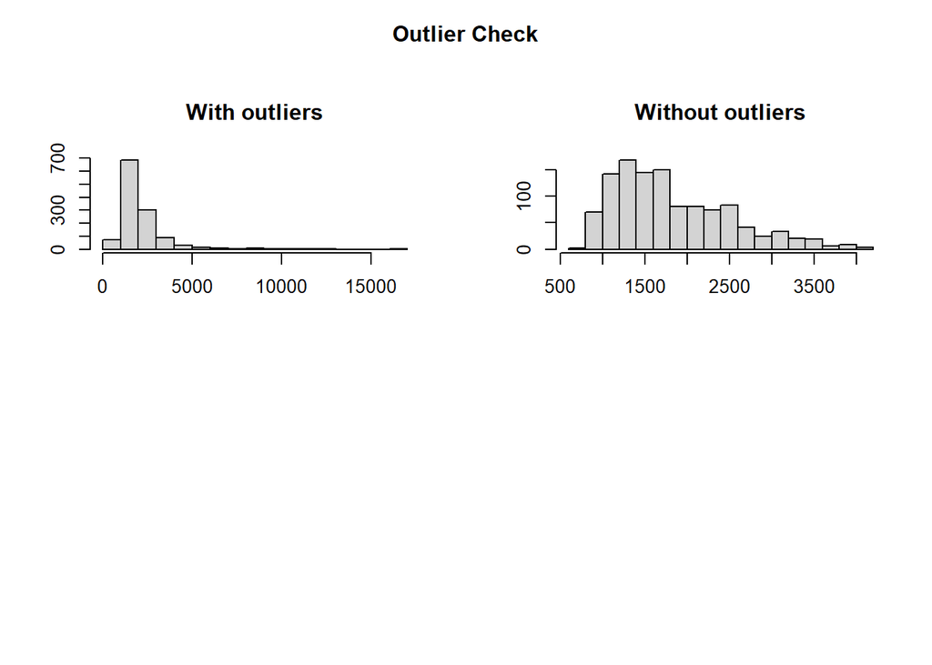

Outliers identified: 72 Propotion (%) of outliers: 6.3 Mean of the outliers: 5489 Mean without removing outliers: 1837 Mean if we remove outliers: 1608 Outliers successfully removed

```r
westcoast_annualClean = outlierKD2(westcoast_annualClean, Price.Diff, rm = TRUE)
```

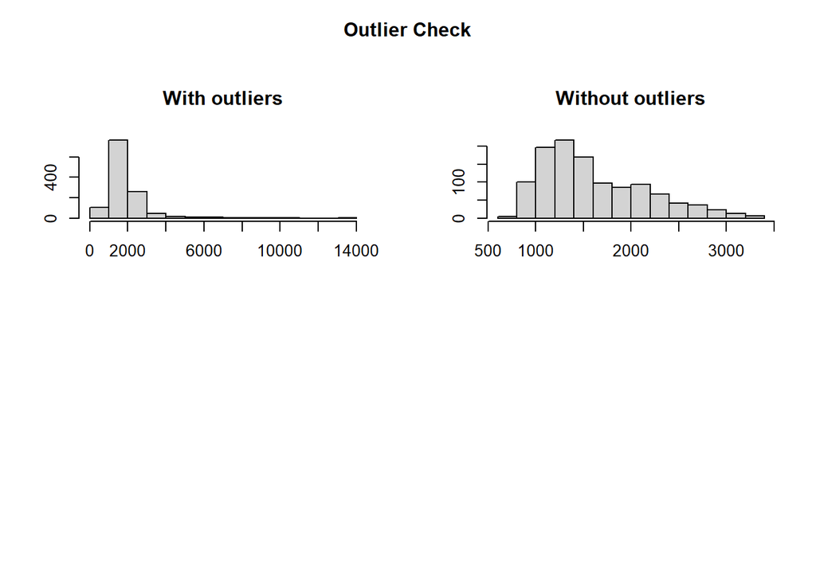

Outliers identified: 76 Propotion (%) of outliers: 6.6 Mean of the outliers: 1512 Mean without removing outliers: 359 Mean if we remove outliers: 283 Outliers successfully removed

```r
eastcoast_annualClean = outlierKD2(eastcoast_annual, November.2010, rm = TRUE)
```

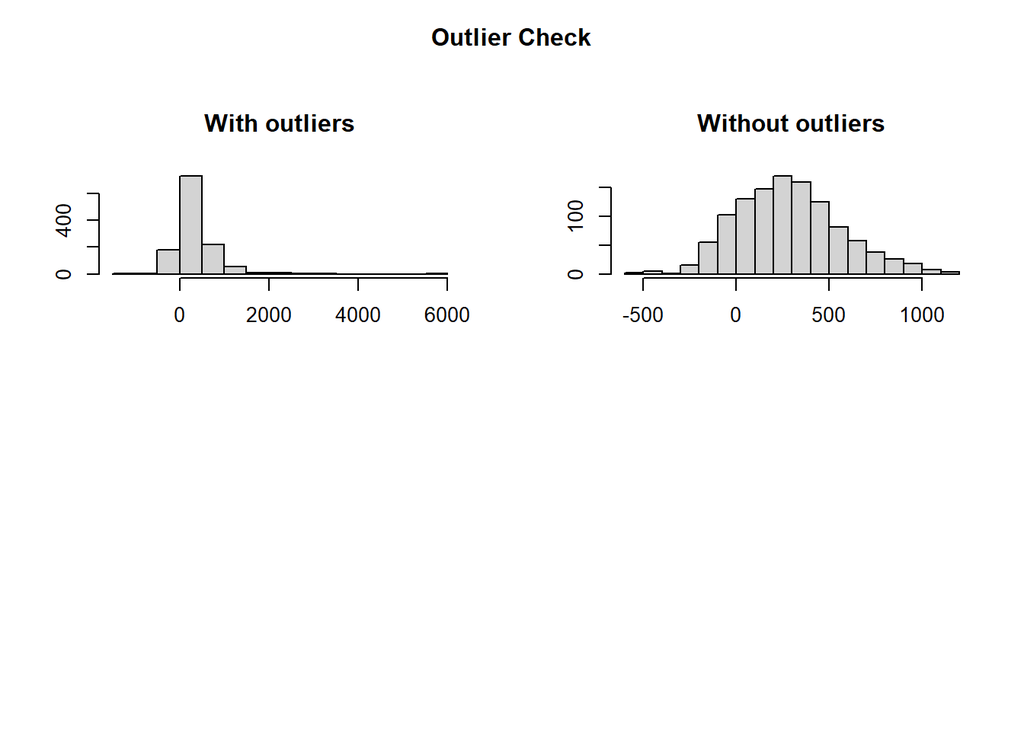

Outliers identified: 171 Propotion (%) of outliers: 4.5 Mean of the outliers: 3417 Mean without removing outliers: 1458 Mean if we remove outliers: 1370 Outliers successfully removed

```r
eastcoast_annualClean = outlierKD2(eastcoast_annualClean, November.2016, rm = TRUE)
```

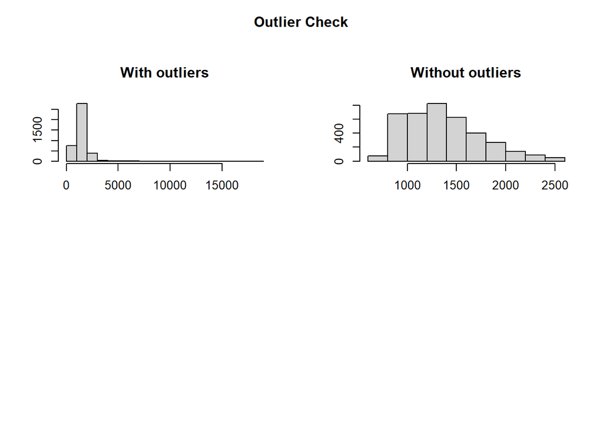

Outliers identified: 162 Propotion (%) of outliers: 4.2 Mean of the outliers: 3953 Mean without removing outliers: 1598 Mean if we remove outliers: 1498 Outliers successfully removed

```r
eastcoast_annualClean = outlierKD2(eastcoast_annualClean, Avg.Price, rm = TRUE)
```

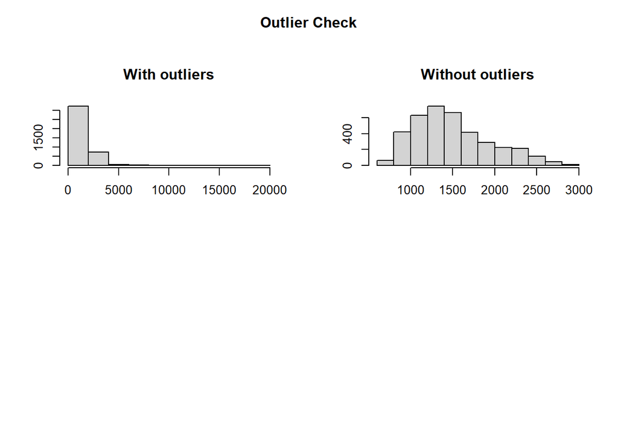

Outliers identified: 171 Propotion (%) of outliers: 4.5 Mean of the outliers: 3583 Mean without removing outliers: 1513 Mean if we remove outliers: 1420 Outliers successfully removed

```r
eastcoast_annualClean = outlierKD2(eastcoast_annualClean, Price.Diff, rm = TRUE)
```

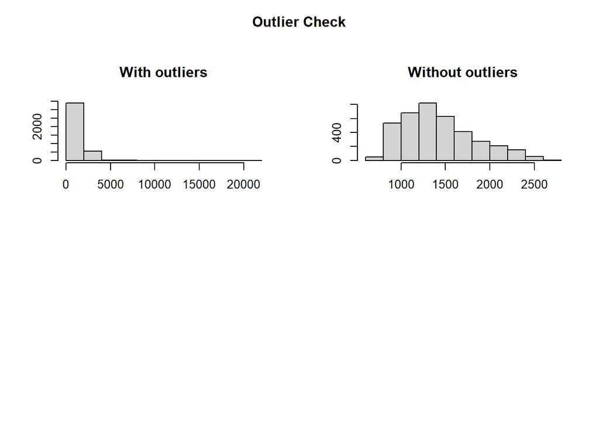

Outliers identified: 168 Propotion (%) of outliers: 4.4 Mean of the outliers: 595 Mean without removing outliers: 140 Mean if we remove outliers: 120 Outliers successfully removed

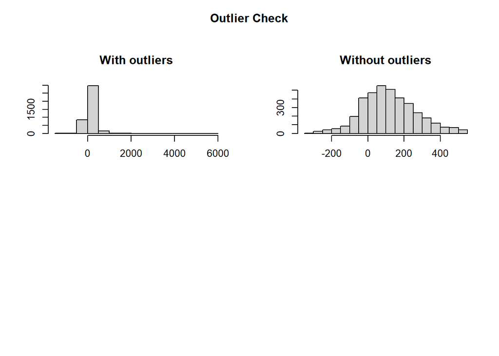

## Transpose Data Correctly

```r
rownames(westAnn) = westAnn$City.Code
westAnn = westAnn[c(-1)]
westAnn = as.data.frame(t(westAnn))
names(westAnn)<-str_replace_all(names(westAnn), c(" " = "" , "," = ""))
westAnn <- cbind(Date = rownames(westAnn), westAnn)
rownames(westAnn) <- 1:nrow(westAnn)
head(westAnn)


rownames(eastAnn) = eastAnn$City.Code
eastAnn = eastAnn[c(-1)]
eastAnn = as.data.frame(t(eastAnn))
names(eastAnn)<-str_replace_all(names(eastAnn), c(" " = "" , "," = ""))
eastAnn <- cbind(Date = rownames(eastAnn), eastAnn)
rownames(eastAnn) <- 1:nrow(eastAnn)
head(eastAnn)
```

## Summary of the two regions annually

```r
# getting the summaries to view basic stats of the data
summary(eastcoast_annual[7:15])
summary(westcoast_annual[7:15])
xkablesummary(westcoast_annual[7:15], title="West Coast Summary Annually")
xkablesummary(eastcoast_annual[7:15], title="East Coast Summary Annually")

xkablesummary(westcoast_annual[c(7,10,13:15)], title="West Coast Summary Annually")
xkablesummary(eastcoast_annual[c(7,10,13:15)], title="East Coast Summary Annually")
```

## Finding the Outliers to Help with Graphs

```r
# checking outliers
outWest2010 <- boxplot.stats(westcoast_annual$November.2010)$out
outWest2016 <- boxplot.stats(westcoast_annual$November.2016)$out
outEast2010 <- boxplot.stats(eastcoast_annual$November.2010)$out
outEast2016 <- boxplot.stats(eastcoast_annual$November.2016)$out
min(outWest2010)
min(outWest2016)
min(outEast2010)
min(outEast2016)
```

## West Coast Annual Novemeber 2010 Start and November 2016 End Histogram

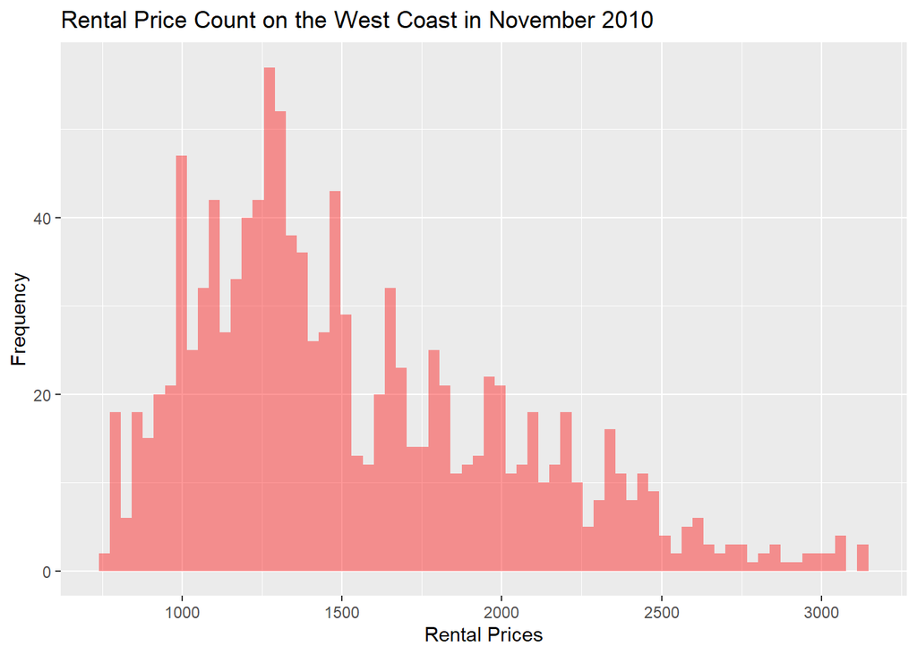

```r
library(ggplot2)
ggplot(westcoast_annualClean, aes(November.2010)) + geom_histogram(fill="red",alpha = 0.4,bins= 70) +
    labs(title = "Rental Price Count on the West Coast in November 2010", x = "Rental Prices", y = "Frequency")
```

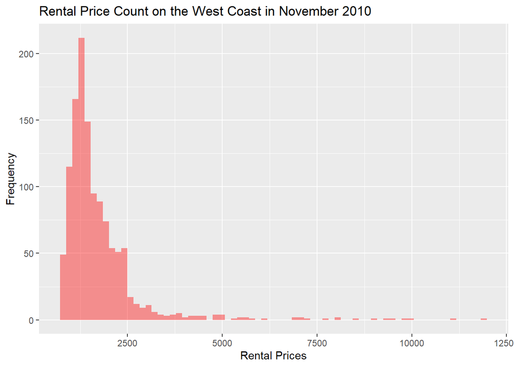

```r
ggplot(westcoast_annual, aes(November.2010)) + geom_histogram(fill="red",alpha = 0.4,bins= 70) +
    labs(title = "Rental Price Count on the West Coast in November 2010", x = "Rental Prices", y = "Frequency")
```

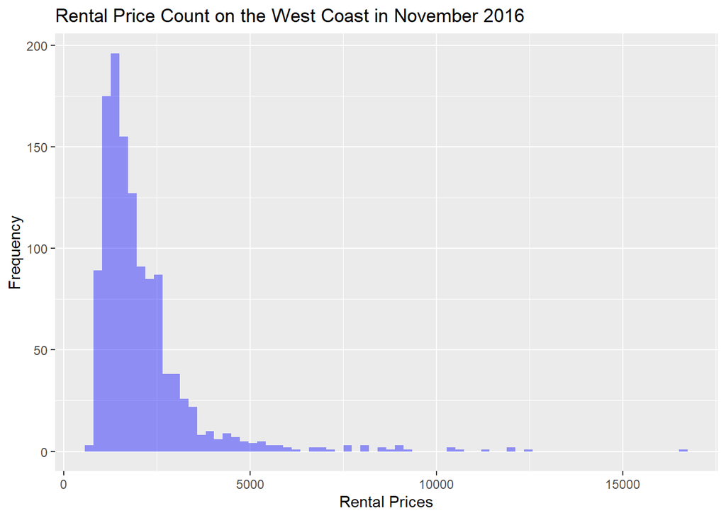

```r
ggplot(westcoast_annual, aes(November.2016)) + geom_histogram(fill="blue",alpha = 0.4,bins= 70) +
    labs(title = "Rental Price Count on the West Coast in November 2016", x = "Rental Prices", y = "Frequency")
```

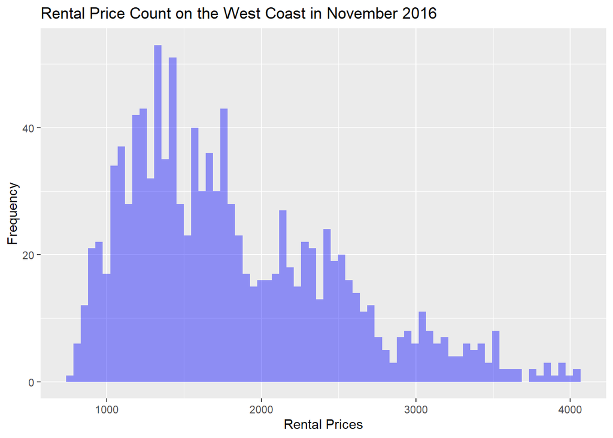

```r
ggplot(westcoast_annualClean, aes(November.2016)) + geom_histogram(fill="blue",alpha = 0.4,bins= 70) +
    labs(title = "Rental Price Count on the West Coast in November 2016", x = "Rental Prices", y = "Frequency")
```

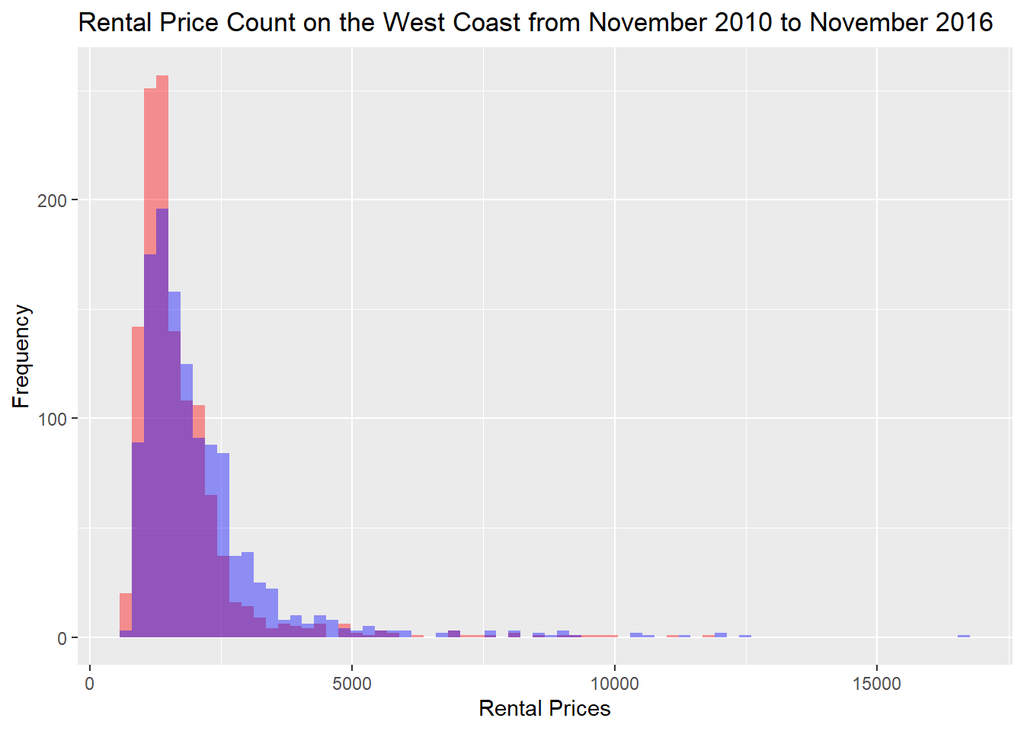

```r
ggplot(westcoast_annual) +
    geom_histogram(aes(November.2010), fill = "red", alpha = 0.4, bins = 70) +
    geom_histogram(aes(November.2016), fill = "blue", alpha = 0.4, bins = 70) +
    labs(title = "Rental Price Count on the West Coast from November 2010 to November 2016", x = "Rental Prices", y = "Frequency")
```

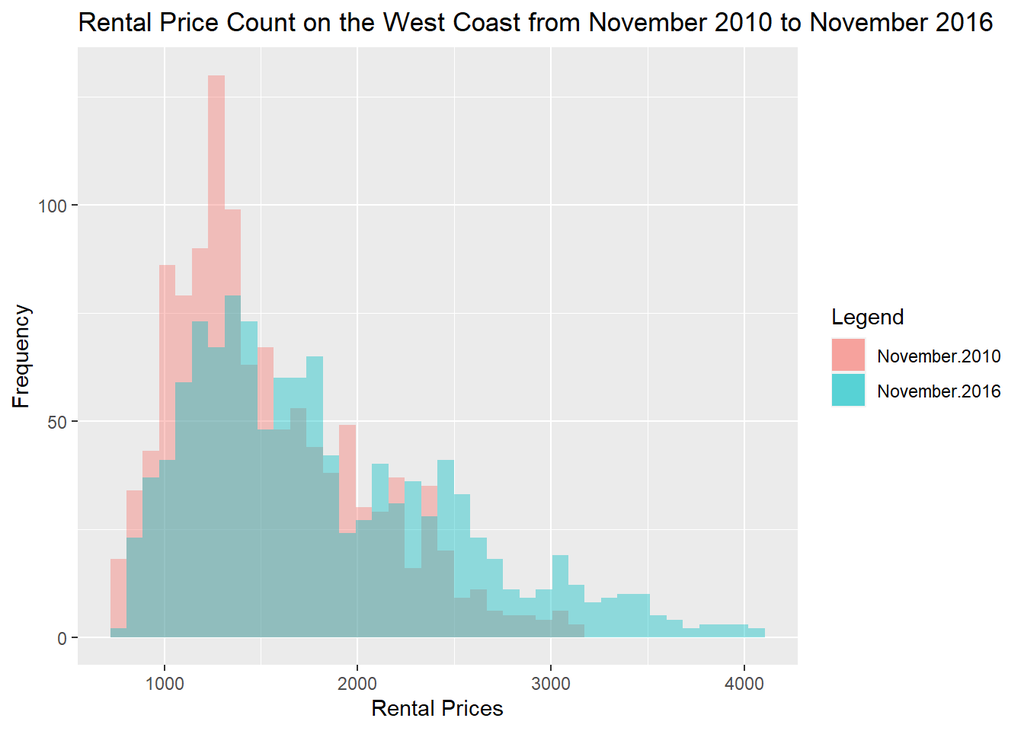

```r
colors <- c("November.2010" = "red", "November.2016" = "blue")

ggplot(westcoast_annualClean) +
    geom_histogram(aes(November.2010, fill = "November.2010"),alpha = 0.4, bins = 40) +
    geom_histogram(aes(November.2016, fill = "November.2016"),alpha = 0.4, bins = 40) +
    labs(title = "Rental Price Count on the West Coast from November 2010 to November 2016", x = "Rental Prices",
         y = "Frequency", fill = "Legend") +
    scale_color_manual(values = colors)
```

## East Coast Annual Novemeber 2010 Start and November 2016 End Histogram

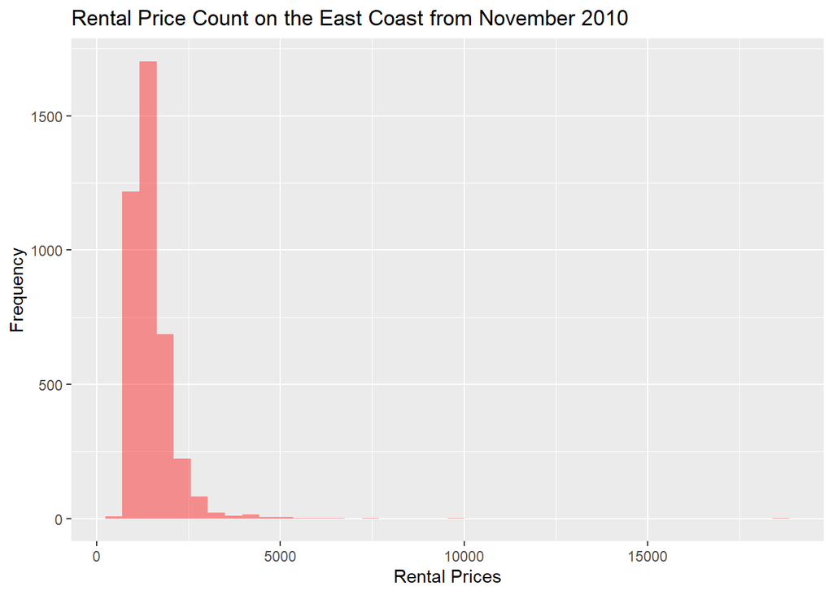

```r
ggplot(eastcoast_annual, aes(November.2010)) + geom_histogram(fill="red",alpha = 0.4,bins= 40) +
    labs(title = "Rental Price Count on the East Coast from November 2010", x = "Rental Prices", y = "Frequency")
```

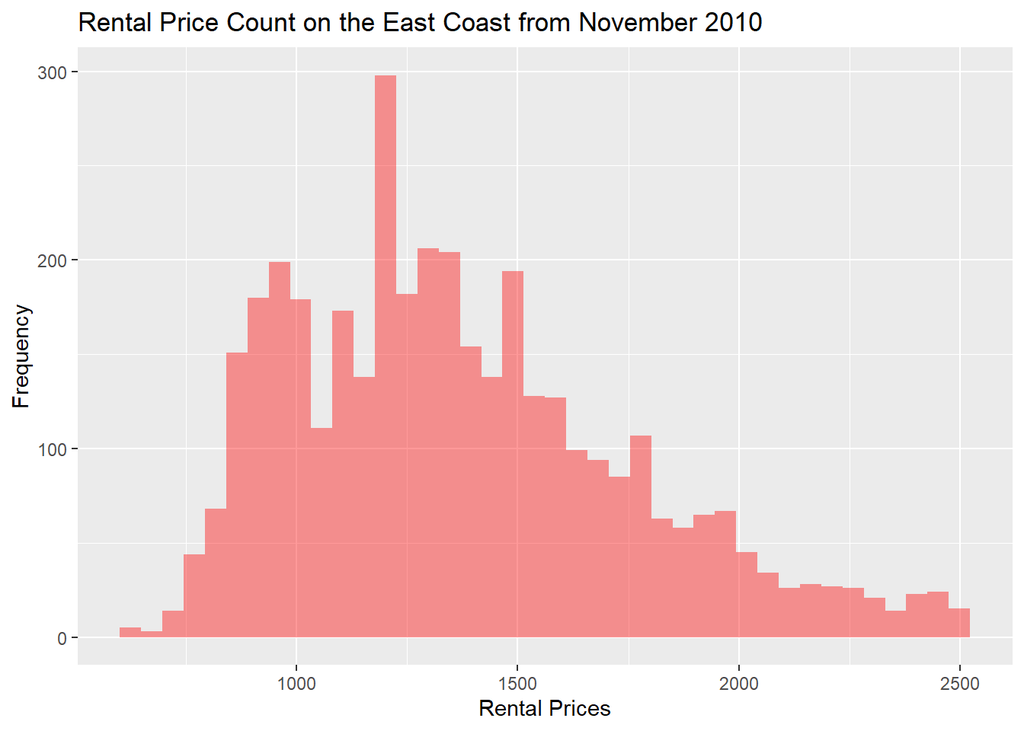

```r
ggplot(eastcoast_annualClean, aes(November.2010)) + geom_histogram(fill="red",alpha = 0.4,bins= 40) +
    labs(title = "Rental Price Count on the East Coast from November 2010", x = "Rental Prices", y = "Frequency")
```

[figure not shown]

```r
ggplot(eastcoast_annual, aes(November.2016)) + geom_histogram(fill="red",alpha = 0.4,bins= 40) +
    labs(title = "Rental Price Count on the East Coast from November 2010", x = "Rental Prices", y = "Frequency")
```

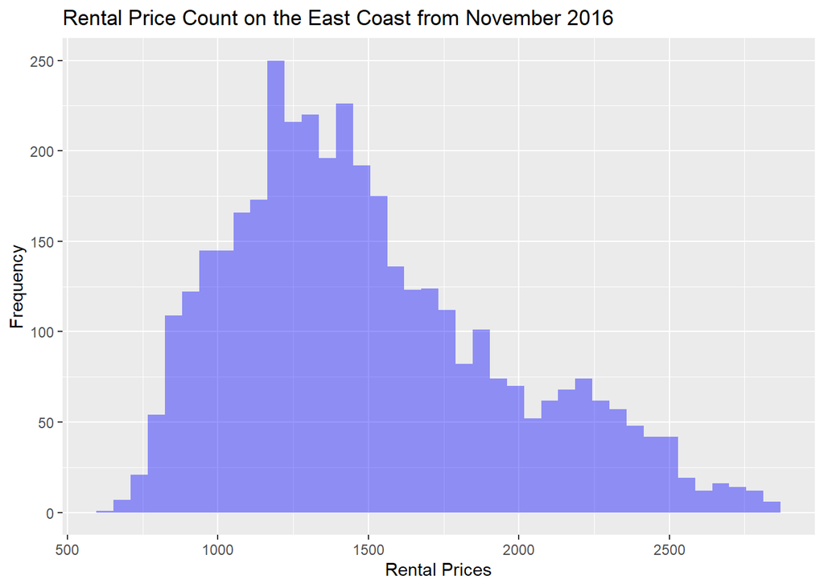

```r
ggplot(eastcoast_annualClean, aes(November.2016)) + geom_histogram(fill="blue",alpha = 0.4,bins= 40) +
    labs(title = "Rental Price Count on the East Coast from November 2016", x = "Rental Prices", y = "Frequency")
```

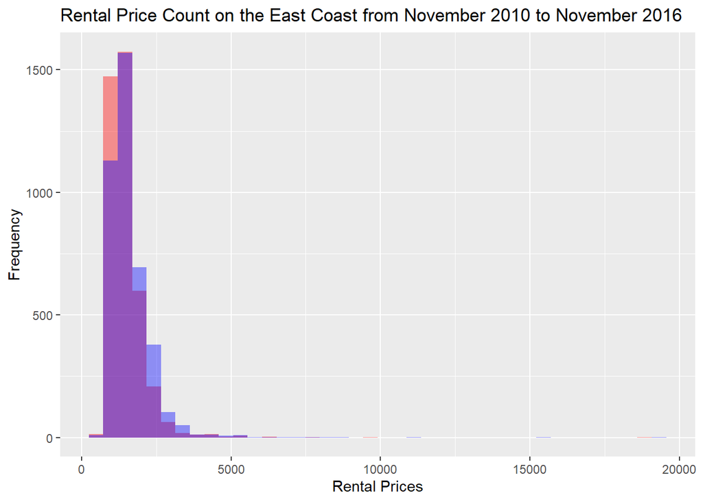

```r
ggplot(eastcoast_annual) +
    geom_histogram(aes(November.2010), fill = "red", alpha = 0.4, bins = 40) +
    geom_histogram(aes(November.2016), fill = "blue", alpha = 0.4, bins = 40) +
    labs(title = "Rental Price Count on the East Coast from November 2010 to November 2016", x = "Rental Prices", y = "Frequency")
```

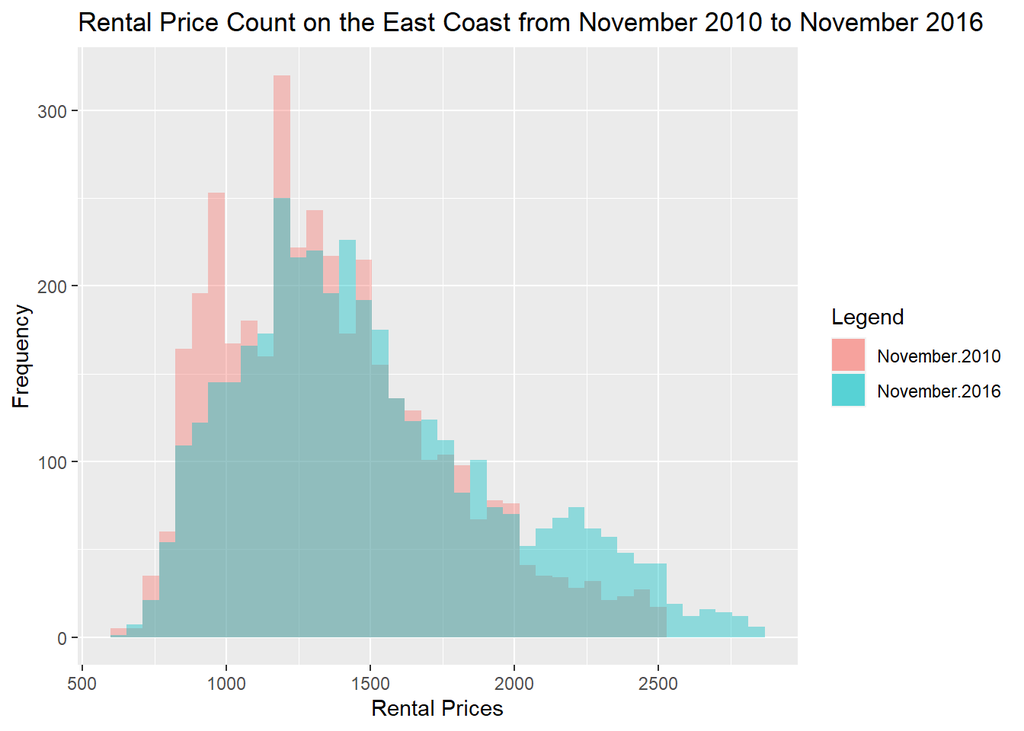

```r
colors <- c("November.2010" = "red", "November.2016" = "blue")

ggplot(eastcoast_annualClean) +
    geom_histogram(aes(November.2010, fill = "November.2010"),alpha = 0.4, bins = 40) +
    geom_histogram(aes(November.2016, fill = "November.2016"),alpha = 0.4, bins = 40) +
    labs(title = "Rental Price Count on the East Coast from November 2010 to November 2016", x = "Rental Prices",
         y = "Frequency", fill = "Legend") +
    scale_color_manual(values = colors)
```

## Boxplot of West Coast Zillow Rental Prices 2010-2016

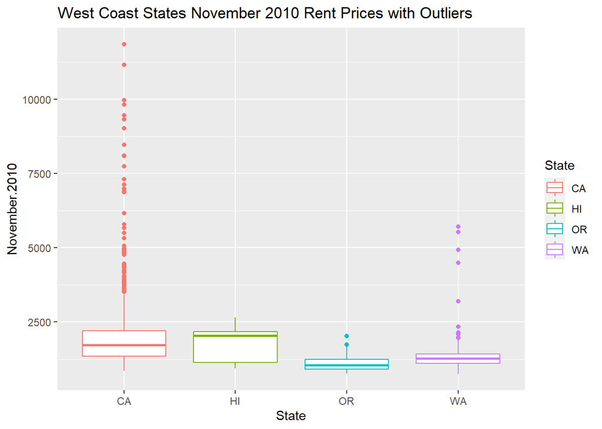

```r
ggplot(westcoast_annual, aes(State, November.2010, color=State)) + geom_boxplot() + labs(title = "West Coast States November 2010 Rent Prices with Outliers")
```

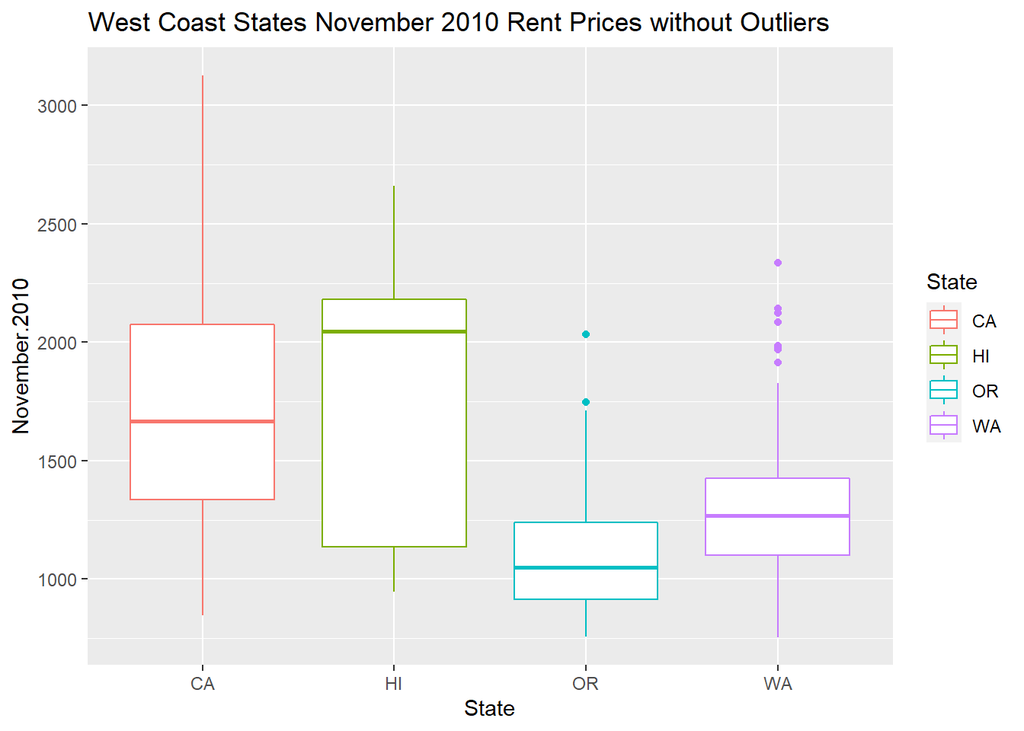

```r
ggplot(westcoast_annualClean, aes(State, November.2010, color=State)) + geom_boxplot()+labs(title = "West Coast States November 2010 Rent Prices without Outliers")
```

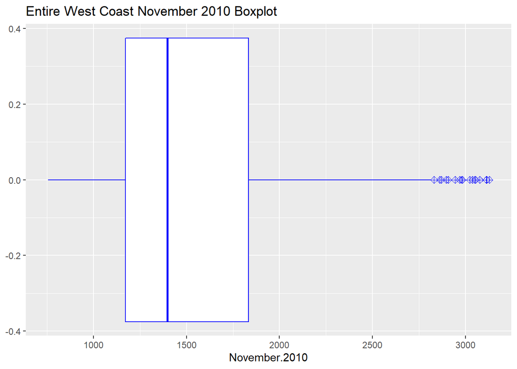

```r
ggplot(westcoast_annualClean, aes(x=November.2010)) + geom_boxplot(color="blue", outlier.shape = 9, outlier.size = 2, outlier.color = "blue") + labs(title="Entire West Coast November 2010 Boxplot") + scale_x_continuous(breaks=seq(500, 4000, 500))
```

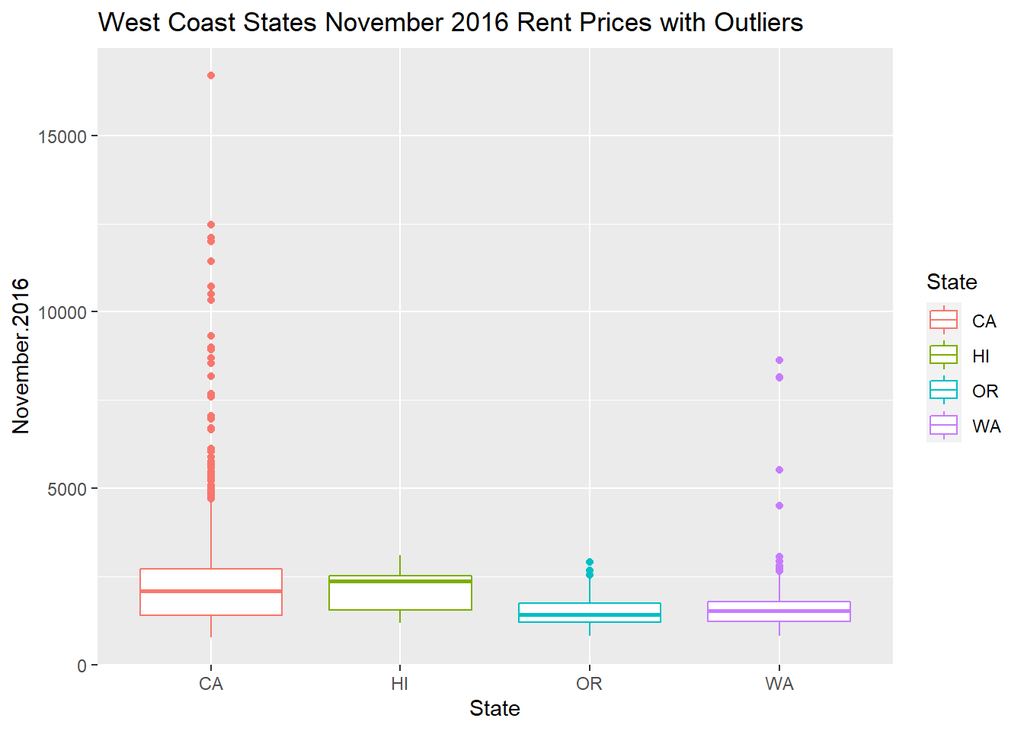

```r
ggplot(westcoast_annual, aes(State, November.2016, color=State)) + geom_boxplot()+labs(title = "West Coast States November 2016 Rent Prices with Outliers")
```

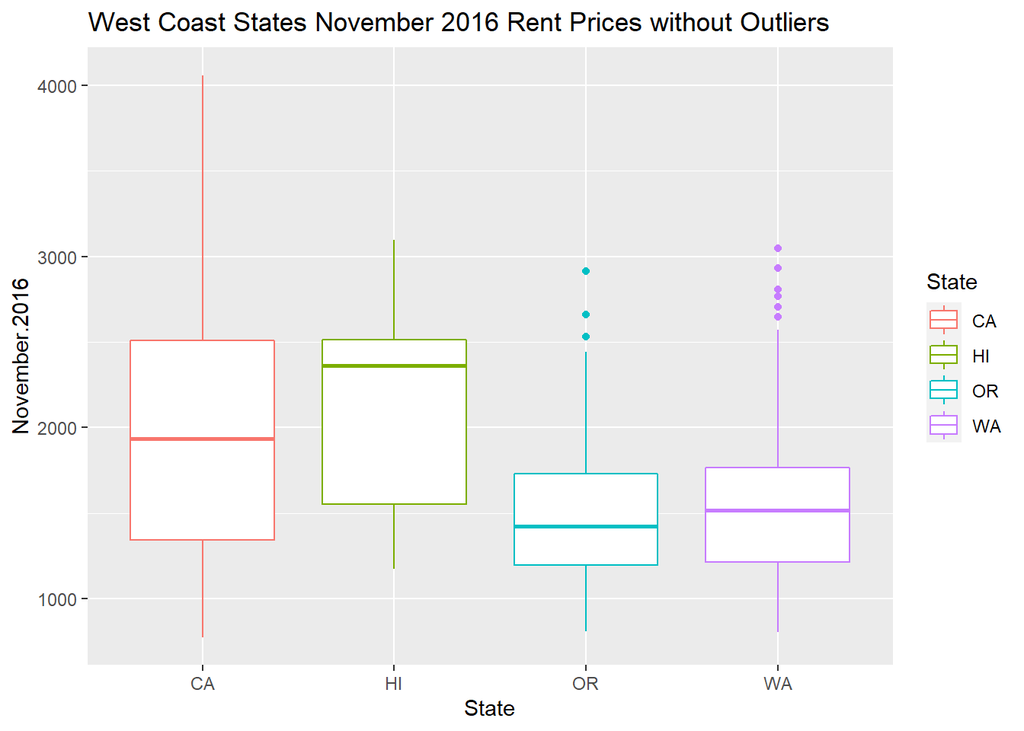

```r
ggplot(westcoast_annualClean, aes(State, November.2016, color=State)) + geom_boxplot()+labs(title = "West Coast States November 2016 Rent Prices without Outliers")
```

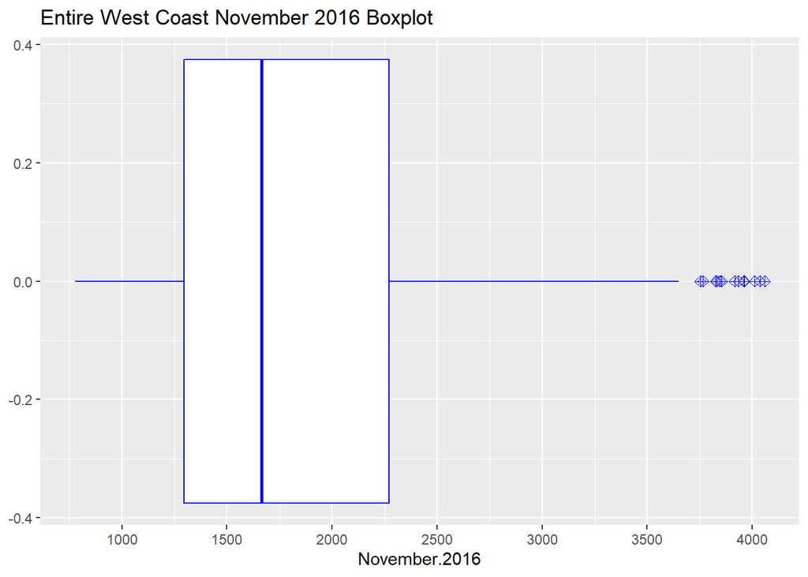

```r
ggplot(westcoast_annualClean, aes(x=November.2016)) + geom_boxplot(color="blue", outlier.shape = 9, outlier.size = 2, outlier.color = "blue") + labs(title="Entire West Coast November 2016 Boxplot") + scale_x_continuous(breaks=seq(500, 4000, 500))
```

## Boxplot of East Coast Zillow Rental Prices 2010-2016

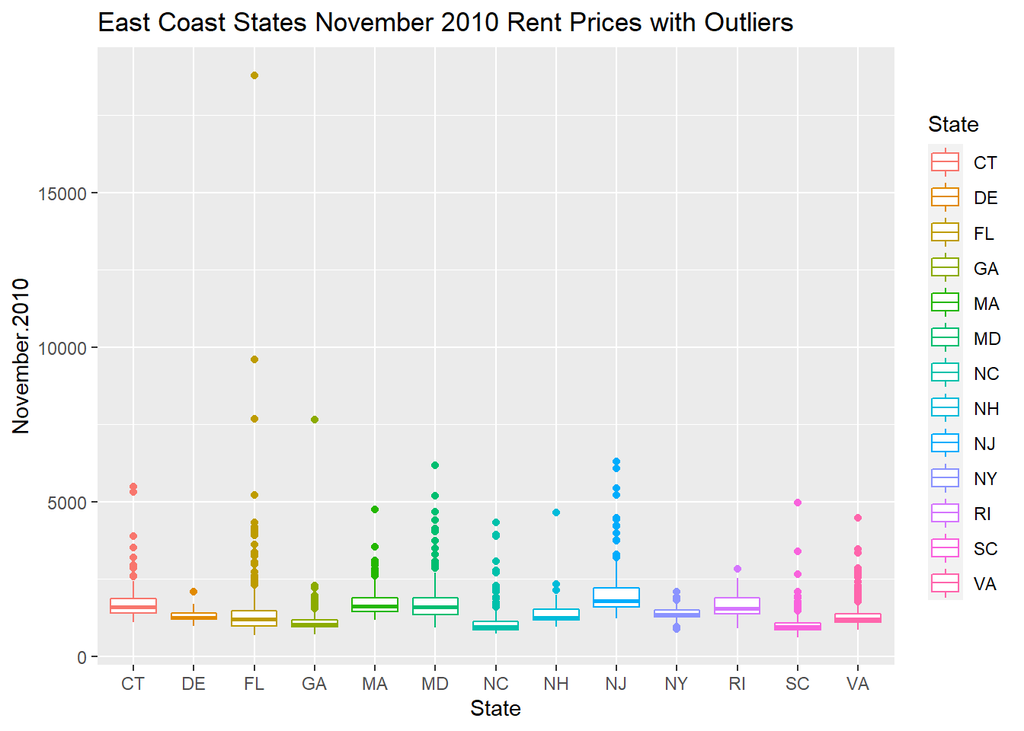

```r
ggplot(eastcoast_annual, aes(State, November.2010, color=State)) + geom_boxplot() + labs(title = "East Coast States November 2010 Rent Prices with Outliers")
```

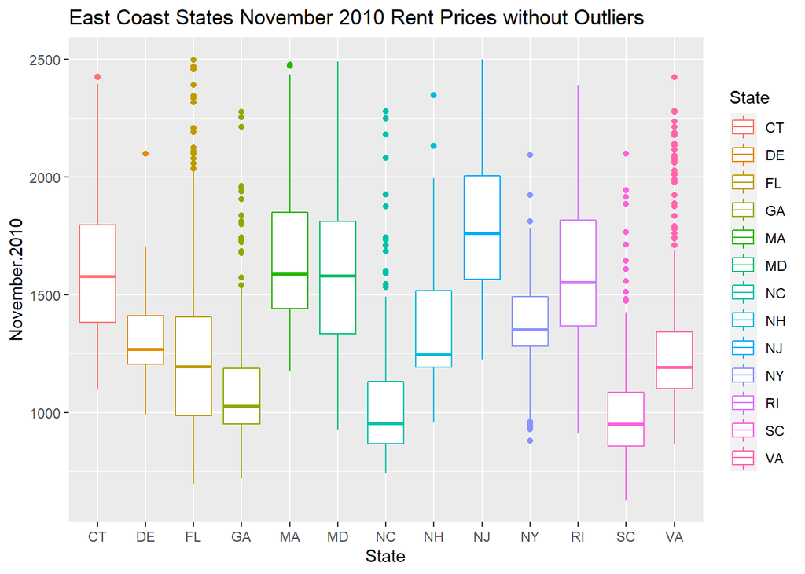

```r
ggplot(eastcoast_annualClean, aes(State, November.2010, color=State)) + geom_boxplot()+labs(title = "East Coast States November 2010 Rent Prices without Outliers")
```

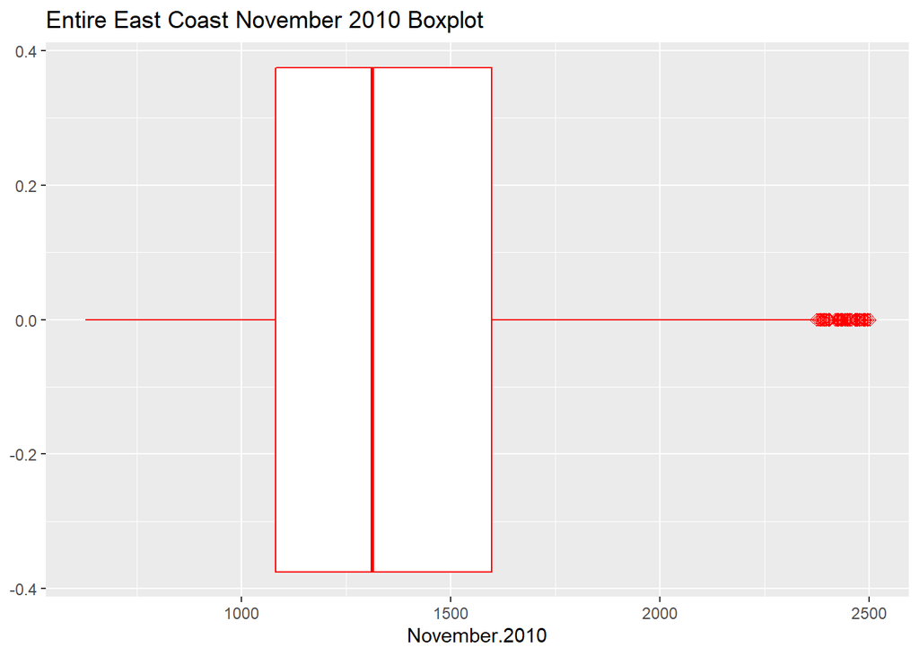

```r
ggplot(eastcoast_annualClean, aes(x=November.2010)) + geom_boxplot(color="red", outlier.shape = 9, outlier.size = 2, outlier.color = "red") + labs(title="Entire East Coast November 2010 Boxplot") + scale_x_continuous(breaks=seq(500, 4000, 500))
```

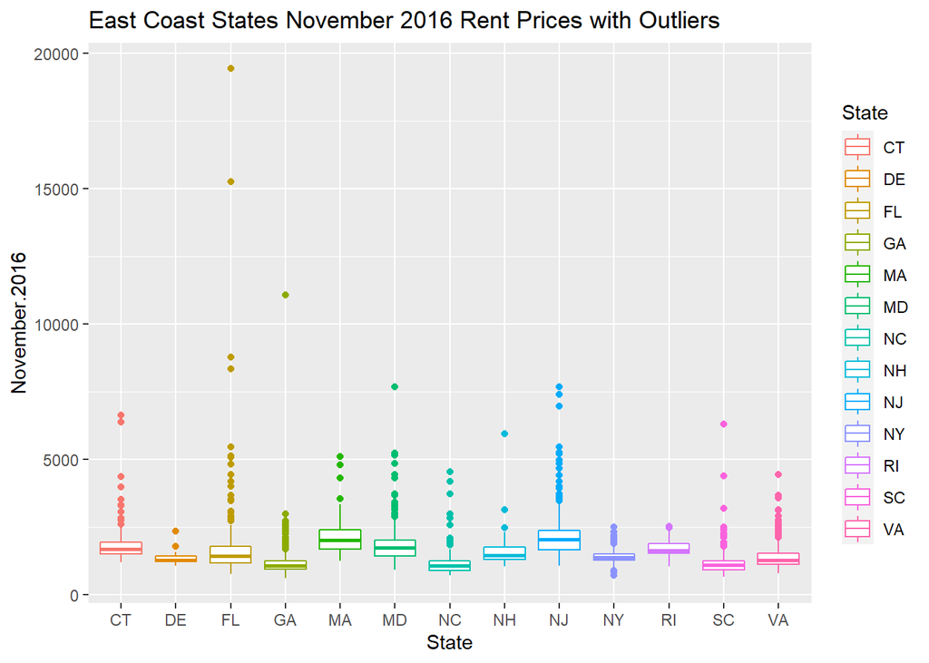

```r
ggplot(eastcoast_annual, aes(State, November.2016, color=State)) + geom_boxplot()+labs(title = "East Coast States November 2016 Rent Prices with Outliers")
```

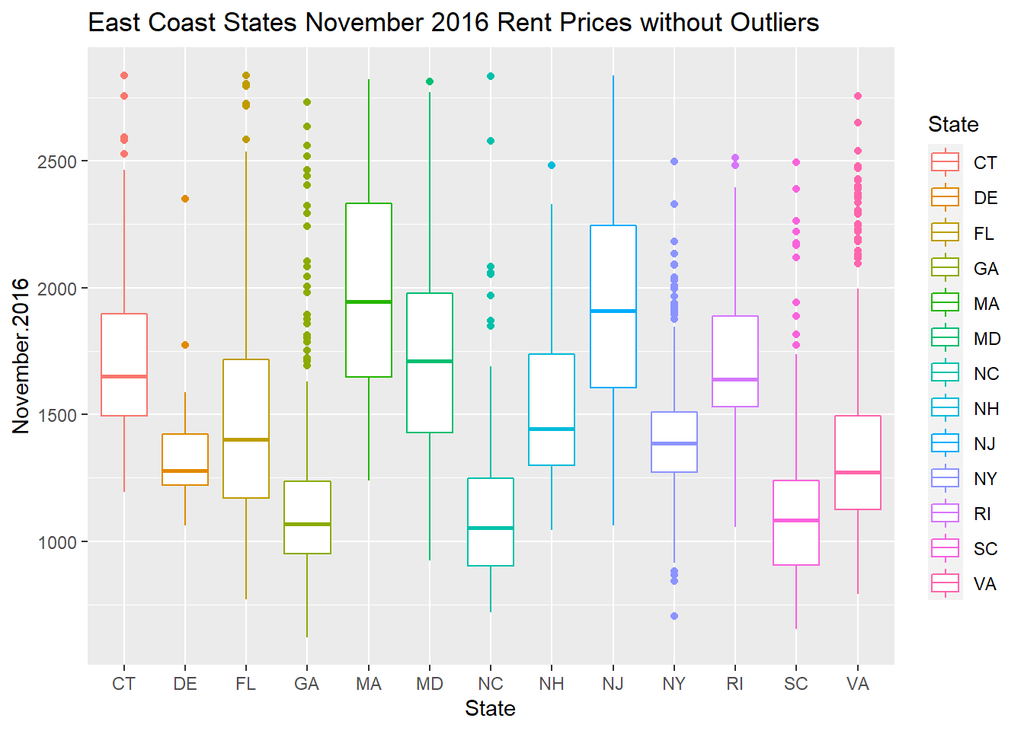

```r
ggplot(eastcoast_annualClean, aes(State, November.2016, color=State)) + geom_boxplot()+labs(title = "East Coast States November 2016 Rent Prices without Outliers")
```

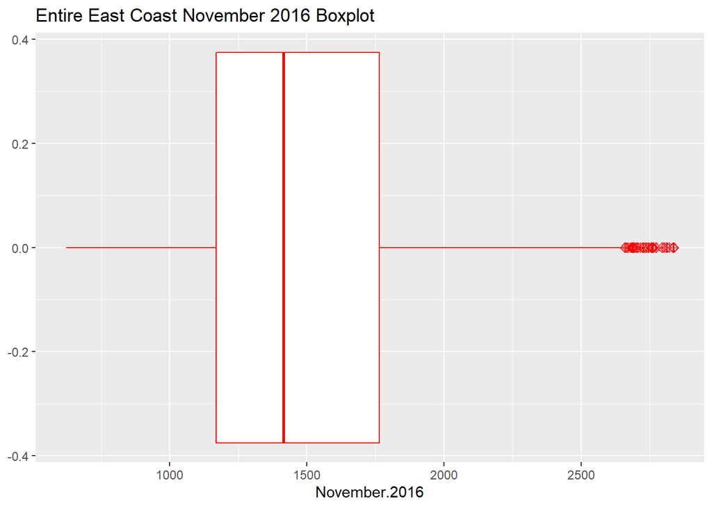

```r
ggplot(eastcoast_annualClean, aes(x=November.2016)) + geom_boxplot(color="red", outlier.shape = 9, outlier.size = 2, outlier.color = "red") + labs(title="Entire East Coast November 2016 Boxplot") + scale_x_continuous(breaks=seq(500, 4000, 500))
```